# Clustering_Practice

Fergus

2025-10-07

## Generating Data From Normal Distributions - A Simple Example

We begin.

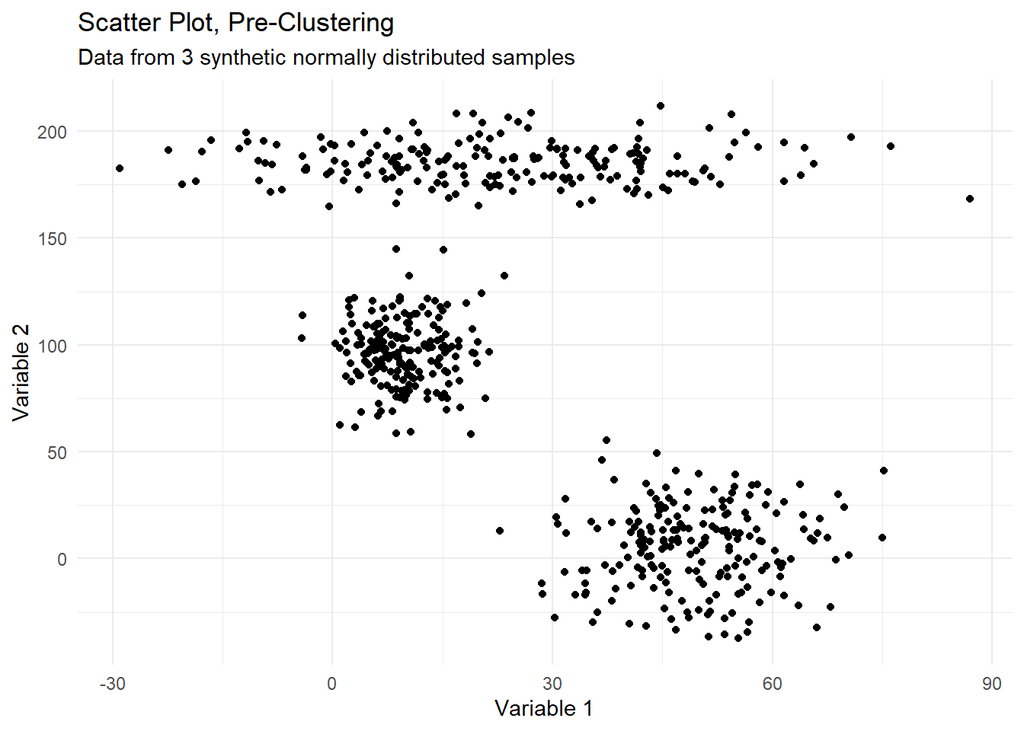

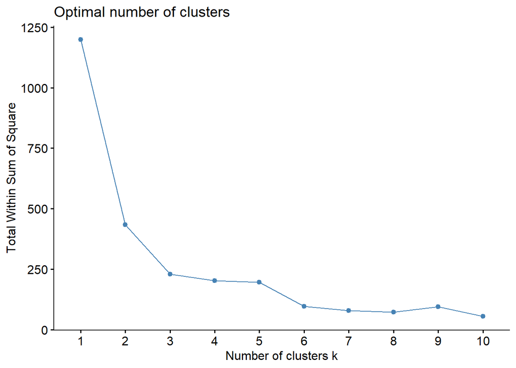

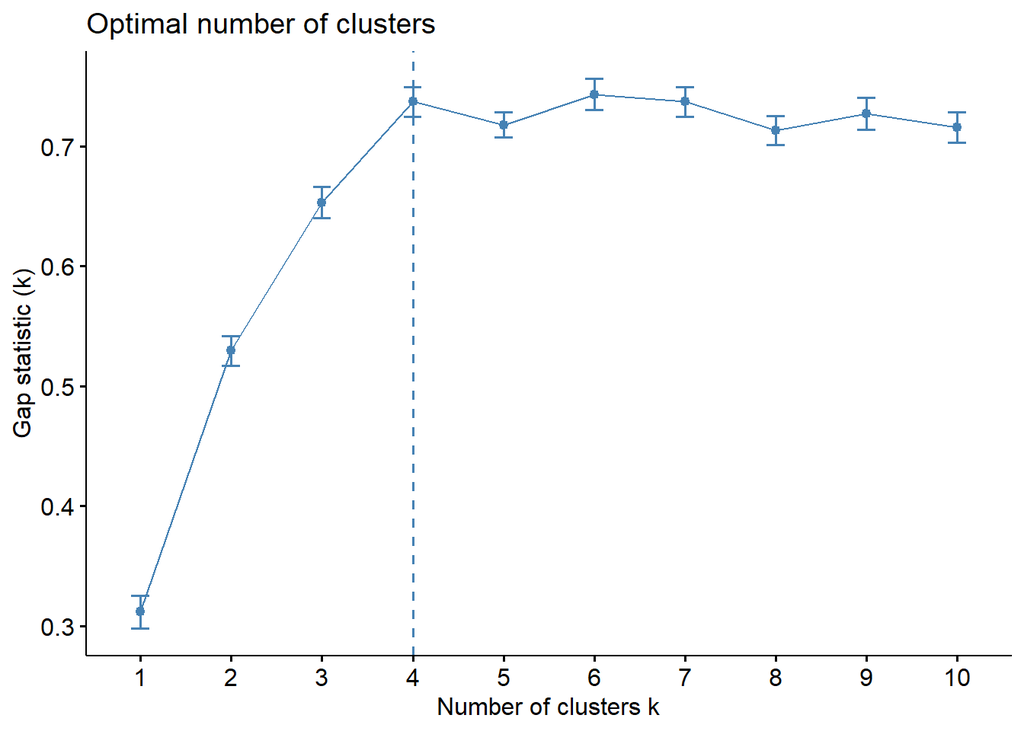

## What is the Gap Statistic? I’ve seen the elbow plot before, which give the total within-group sum of squared residuals. From https://www.statology.org/k-means-clustering-in-r/, it’s given as a comparison between the “total intra-cluster variation for different values of k with their expected values for a distribution with no clustering”.

Gap statistic calculation given:
$$Gap(k) = \frac{1}{B} \Sigma^B_{b=1} (W^b_k - W_k)$$
Where $W_k$ the WSS for the actual clusters; $W^b_k$ the WSS for the reference data with k clusters; $B$ the number of reference datasets used.

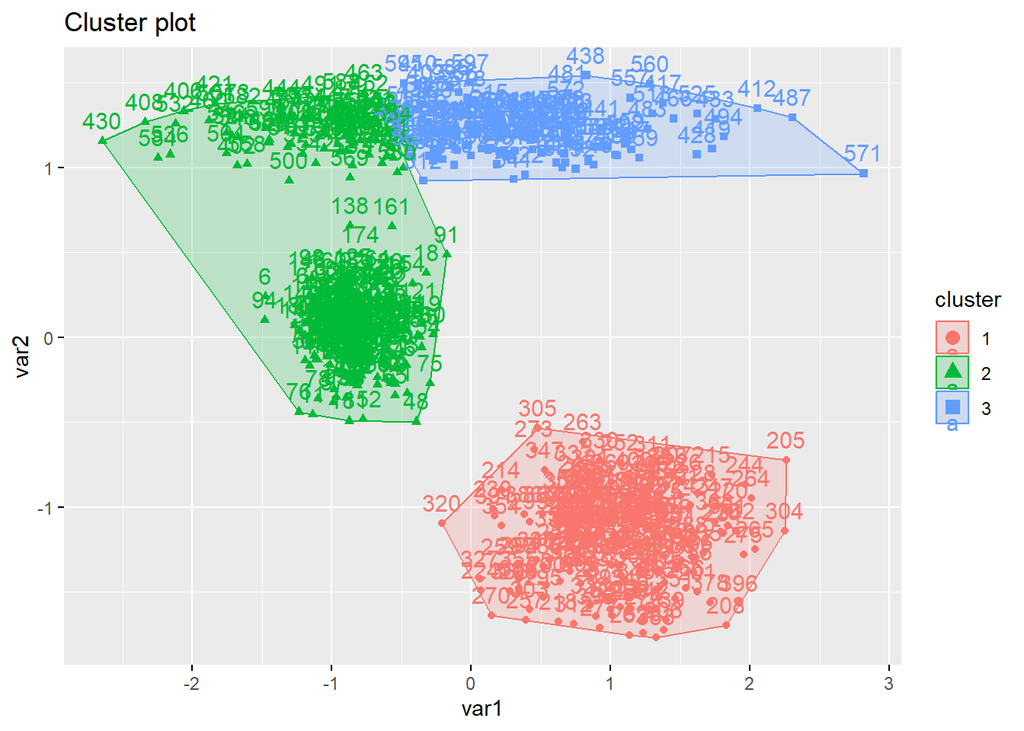

## How Does the Quality of the Clustering Change With Dimension?

First order of business is getting a function that can give us a number of observations normally distributed on n features. By generalising up to n features, we choose to drop the ability to specify the mean and sd of these normal dists.

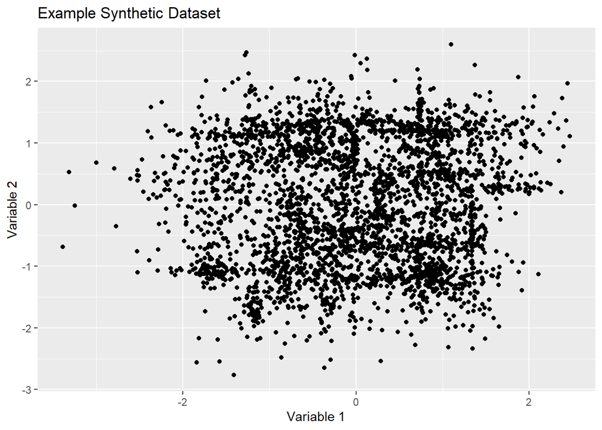